# Fruit Data

Catherine Gubert

Friday, October 17, 2014

## Measuring Fruit Size to Help Map Genetic Pathways in *Arabidopsis*

###### Introduction

*Arabidopsis thaliana* has been a popular model organism for the study of genetic function due to its simplicity and knowledge of its genome. Cell separation and organ abscission is a common biological process among plants that allows them to shed organs such as ripened fruit or dead leaves. In an effort to understand a signaling pathway involved in this process, a set mutants known to affect this process were crossed together and the resulting phenotypes were analyzed. NEVERSHED (NEV) is thought to assist with trafficking of cargo between endosomes and the extracelluar space. Mutations in this gene block the shedding of outer floral organs in *Arabidopsis* flowers and reduce the length of mature fruit. EVERSHED (EVR) encodes a receptor-like kinase that, when supressed with *nev*, rescues abscission and organ shedding. However, it has also been observed that the *nev evr* double mutant does not rescue WT fruit length, suggesting that the pathways for control of abscission and fruit development are separate, though they are both affected by these two genes. Two other receptor-like kinases, HAESA (HAE) and HAESA-LIKE2(HSL2), act redundantly to switch on the production of enzymes required for cell separation. The peptide INFLORESCENCE DEFICIENT IN ABSCISSION (IDA) is the proposed ligand for both receptors. Loss of HAE/HSL2 function in *nev evr* flowers prevents organ shedding. To investigate the role of HAE and HSL2 in fruit development in relation to NEV, EVR, and IDA, the following mutant crosses were generated: *evr*, *nev*, *nev evr*, *nev evr hae*, *nev evr hae hsl2*, and *nev evr ida*. This report seeks to confirm that *nev* and *evr* significantly reduce fruit growth as compared to WT. It is expected that HAE and HSL2 act redundantly in controlling fruit growth, either to promote or reduce fruit length.

###### Background and Data

The raw data for this analysis were kindly shared by Dr. Sarah Liljegren at the University of Mississippi. All background information, methods, and references can be found in [HAESA and HAESA-LIKE2 activate organ abscission downstream of NEVERSHED and EVERSHED in *Arabidopsis* flowers](https://www.landesbioscience.com/journals/psb/article/29115/), a short communication published in Plant Signaling and Behavior, Landes Bioscience, 2014.

Using NIH ImageJ, 30 mature fruit of each genotype were measured lengthwise. The measurments of the mutant fruit were compared to the measurments of wild-type. Several theoretical maps of the signaling pathways involving NEV, EVR, HAE, HSL2, and IDA were deduced from organ shedding and fruit length data. Organ shedding data and proposed signaling pathways are not shown here.

###### Statistical Methods

The original data set was separated into two groups, with the first containing data collected from WT, *evr*, *nev*, *nev evr hae*, and *nev evr hae hsl2* and the second group containing measurments from WT, *nev evr*, and *nev evr ida* fruit. For the purposes of this report, the measurments from the second set of WT fruit were not used. Although data from *nev evr* and *nev evr ida* fruit were collected on a separate date from the other data, all representative fruit was within the same growth stage.

```r
fruitdata
```

```
##       WT    nev    evr nevevr nevevrhae nevevrhaehsl nevidaevr
## 1  12.63  9.931 11.964  7.418     7.295       10.083     7.225
## 2  13.44 10.787 11.205  7.588     7.446       10.358     8.009
## 3  13.16  9.810 11.015  6.498     7.106        9.941     8.511
## 4  13.21  9.982 10.923  7.505     6.770       10.142     8.937
## 5  13.04 10.402 10.742  7.240     6.476        9.426     8.006
## 6  13.34 10.234 11.217  7.085     7.238       10.200     8.403
## 7  12.87  9.650 10.246  6.371     8.207       10.067     7.453
## 8  13.51  9.492 11.073  7.213     7.525       10.129     7.619
## 9  12.28 10.616 10.589  6.538     7.484        9.974     9.247
## 10 12.96 10.164 11.267  8.003     7.942       10.315     8.454
## 11 13.15  9.485  9.947  7.862     6.708       11.285     7.624
## 12 13.58  8.782 10.852  7.950     7.466       10.855     8.701
## 13 13.34  9.707 10.539  7.596     8.516       10.406     8.741
## 14 14.03  9.713 10.746  6.868     8.016        9.524     8.094
```

[output cut: 16 more lines]

A bar plot was generated to illustrate the average lengths of mutant fruit as compared to wild-type.

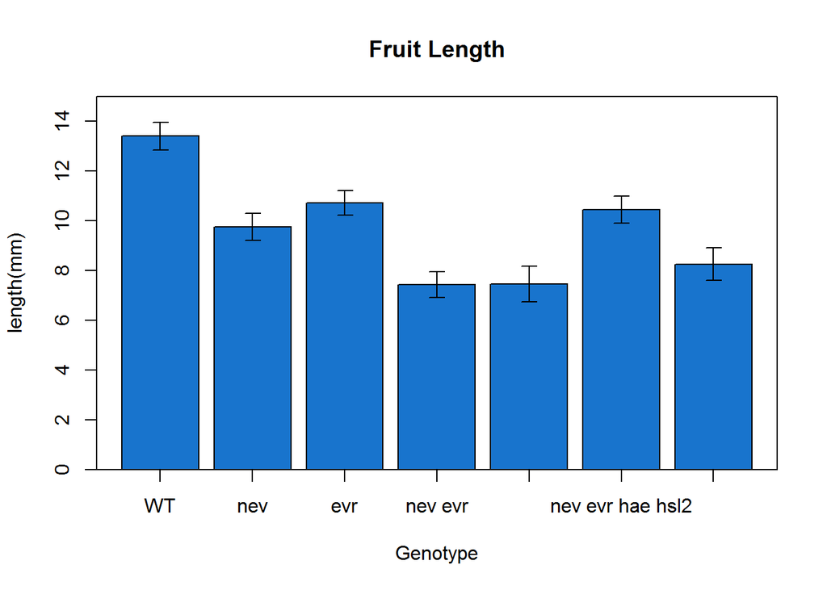

```
## Analysis of Variance Table
##
## Response: data
##            Df Sum Sq Mean Sq F value Pr(>F)
## groups      6    825   137.5     408 <2e-16 ***
## Residuals 203     68     0.3
## ---
## Signif. codes:  0 '***' 0.001 '**' 0.01 '*' 0.05 '.' 0.1 ' ' 1
```

```
##
##  Welch Two Sample t-test
##
## data:  fruitdata$nevidaevr and fruitdata$nevevr
## t = 5.31, df = 56.36, p-value = 1.929e-06
## alternative hypothesis: true difference in means is not equal to 0
## 95 percent confidence interval:
##  0.5117 1.1315
## sample estimates:
## mean of x mean of y
##     8.257     7.436
```

The *nev evr ida* mutant fruit are 78.9743% of *nev evr hae hsl2* fruit. The removal of IDA activity does not restore fruit growth as much as the blocking of HAE/HSL2.

```
##
##  Welch Two Sample t-test
##
## data:  fruitdata$nevevrhaehsl and fruitdata$nevidaevr
## t = 12.48, df = 57.46, p-value < 2.2e-16
## alternative hypothesis: true difference in means is not equal to 0
## 95 percent confidence interval:
##  1.846 2.551
## sample estimates:
## mean of x mean of y
##    10.456     8.257
```

```
##
##  Pairwise comparisons using t tests with pooled SD
##
## data:  data and groups
##
##              evr     nev     nevevr  nevevrhae nevevrhaehsl nevidaevr
## nev          4.7e-09 -       -       -         -            -
## nevevr       < 2e-16 < 2e-16 -       -         -            -
## nevevrhae    < 2e-16 < 2e-16 0.83    -         -            -
## nevevrhaehsl 0.16    1.4e-05 < 2e-16 < 2e-16   -            -
## nevidaevr    < 2e-16 < 2e-16 6.3e-07 1.4e-06   < 2e-16      -
## WT           < 2e-16 < 2e-16 < 2e-16 < 2e-16   < 2e-16      < 2e-16
##
## P value adjustment method: holm
```